# Advanced Semantic Segmentation Architectures - Part 2

## DeepLabV3+

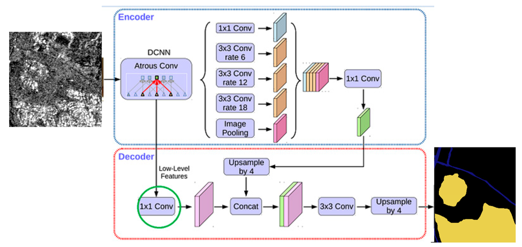

DeepLabv3+ extends DeepLabv3 by adding an encoder-decoder framework. The encoder module processes multi-scale contextual information by applying multi-scale dilated convolution, while the decoder module refines the segmentation results along object boundaries.

Dilated Convolution: With dilated convolution, as we go deeper into the network, we can keep the stride constant but have a larger field of view without increasing the number of parameters or the amount of computation. It also allows for larger output feature maps, which is useful for semantic segmentation.

The reason for using Dilated Spatial Pyramid Pooling is that it has been shown that as the sampling rate increases, the number of valid filter weights (i.e., weights applied to the valid feature region, rather than padded zeros) becomes smaller.

Multiple downsampling of a CNN will lead to the resolution of the feature map becoming smaller, resulting in lower prediction accuracy and loss of boundary information in semantic segmentation. Similarly, adding context around a feature helps in segmenting it better, which is done with atrophic convolutions. DeepLabv3+ helps solve these problems.

### Atrous rate

Atrous Convolution/Dilated Convolution is a tool to refine the effective field of view of the convolution. It modifies the field of view using a parameter called atrous rate. It is a simple yet powerful approach to enlarge the field of view of filters without affecting the computation or the number of parameters.

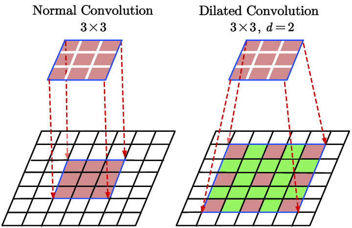

### Atrous Separable Convolution

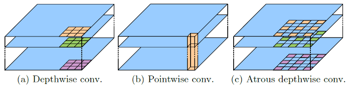

(a) and (b), Depthwise Separable Convolution: Factorizes a standard convolution into a depthwise convolution followed by a pointwise convolution (i.e., 1×1 convolution), drastically reduces the computation complexity.

(c) Depthwise Atrous Convolution: Atrous convolution is supported on depthwise convolution. And it is found to significantly reduce the computation complexity of the proposed model while maintaining similar (or better) performance. Combining with pointwise convolution, it is the separable atrous convolution.

So, let's implement DeepLabV3+:

```python
from google.colab import drive
drive.mount('/content/drive')
```

```python
import glob
import os
import cv2
import numpy as np
import matplotlib.pyplot as plt
from keras.utils import to_categorical
from sklearn.model_selection import train_test_split
from sklearn.metrics import accuracy_score
from skimage import io
import os, csv
```

We configure the paths of the RGB image, the mask and the color table of the classes.

```python
image_path = '/content/drive/MyDrive/Datasets/Cana weeds/sugarcane2.png'
mask_path = '/content/drive/MyDrive/Datasets/Cana weeds/crop6GT.png'
class_path = '/content/drive/MyDrive/Datasets/Cana weeds/class_dict.csv'
```

Let's open and plot the image and mask:

```python
rgb_img = io.imread(image_path)
msk_img = io.imread(mask_path)
```

```
(-0.5, 5363.5, 6814.5, -0.5)
```

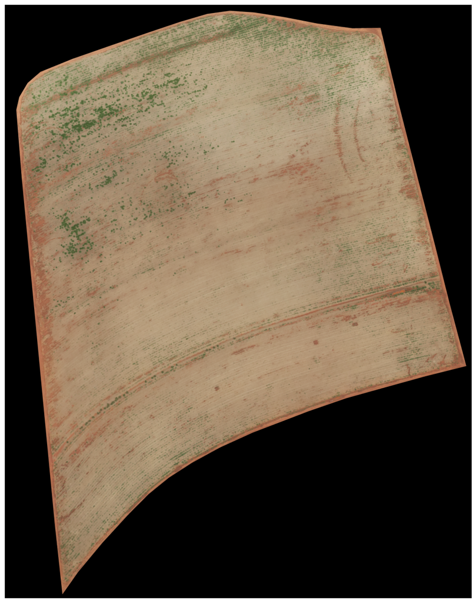

```python
plt.figure(figsize=[16,16])
plt.imshow(rgb_img)
plt.axis('off')
```

```
(-0.5, 5363.5, 6814.5, -0.5)
```

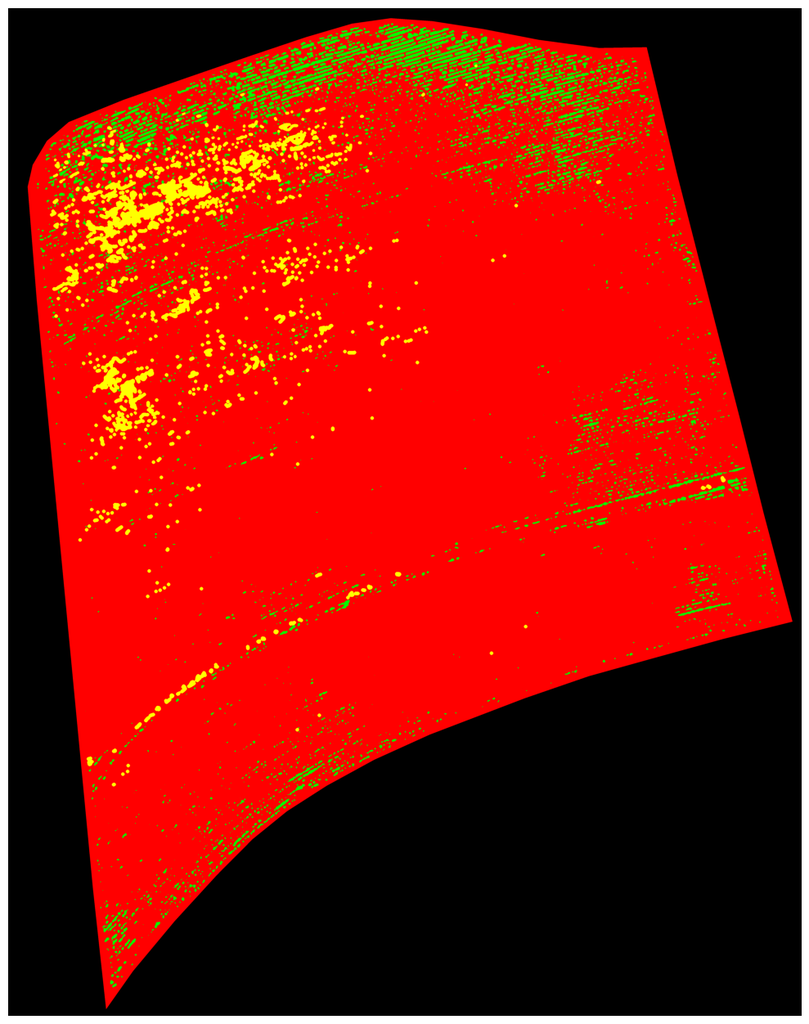

```python
plt.figure(figsize=[16,16])
plt.imshow(msk_img)
plt.axis('off')
```

The mask is composed of an RGB image where each color represents a class. We need to categorize and convert the values of these colors to an image of a band with integer values for each class. To do this, we will create some functions to make this easier:

```python
def get_label_info(csv_path):
    """
    Retrieve the class names and label values for the selected dataset.
    Must be in CSV format!

    # Arguments
        csv_path: The file path of the class dictionairy

    # Returns
        Two lists: one for the class names and the other for the label values
    """
    filename, file_extension = os.path.splitext(csv_path)
    if not file_extension == ".csv":
        return ValueError("File is not a CSV!")

    class_names = []
    label_values = []
    with open(csv_path, 'r') as csvfile:
        file_reader = csv.reader(csvfile, delimiter=',')
        header = next(file_reader)
        for row in file_reader:
            class_names.append(row[0])
            label_values.append([int(row[1]), int(row[2]), int(row[3])])
        # print(class_dict)
    return class_names, label_values
```

```python
def one_hot_it(label, label_values):
    """
    Convert a segmentation image label array to one-hot format
    by replacing each pixel value with a vector of length num_classes

    # Arguments
        label: The 2D array segmentation image label
        label_values

    # Returns
        A 2D array with the same width and hieght as the input, but
        with a depth size of num_classes
    """
    # st = time.time()
    # w = label.shape[0]
    # h = label.shape[1]
    # num_classes = len(class_dict)
    # x = np.zeros([w,h,num_classes])
    # unique_labels = sortedlist((class_dict.values()))
    # for i in range(0, w):
    #     for j in range(0, h):
    #         index = unique_labels.index(list(label[i][j][:]))
    #         x[i,j,index]=1
    # print("Time 1 = ", time.time() - st)

    # st = time.time()
    # https://stackoverflow.com/questions/46903885/map-rgb-semantic-maps-to-one-hot-encodings-and-vice-versa-in-tensorflow
    # https://stackoverflow.com/questions/14859458/how-to-check-if-all-values-in-the-columns-of-a-numpy-matrix-are-the-same
    semantic_map = []
    for colour in label_values:
        # colour_map = np.full((label.shape[0], label.shape[1], label.shape[2]), colour, dtype=int)
        equality = np.equal(label, colour)
        class_map = np.all(equality, axis = -1)
        semantic_map.append(class_map)
    semantic_map = np.stack(semantic_map, axis=-1)
    # print("Time 2 = ", time.time() - st)

    return semantic_map

def reverse_one_hot(image):
    """
    Transform a 2D array in one-hot format (depth is num_classes),
    to a 2D array with only 1 channel, where each pixel value is
    the classified class key.

    # Arguments
        image: The one-hot format image

    # Returns
        A 2D array with the same width and hieght as the input, but
        with a depth size of 1, where each pixel value is the classified
        class key.
    """
    # w = image.shape[0]
    # h = image.shape[1]
    # x = np.zeros([w,h,1])

    # for i in range(0, w):
    #     for j in range(0, h):
    #         index, value = max(enumerate(image[i, j, :]), key=operator.itemgetter(1))
    #         x[i, j] = index

    x = np.argmax(image, axis = -1)
    return x


def colour_code_segmentation(image, label_values):
    """
    Given a 1-channel array of class keys, colour code the segmentation results.

    # Arguments
        image: single channel array where each value represents the class key.
        label_values

    # Returns
        Colour coded image for segmentation visualization
    """

    # w = image.shape[0]
    # h = image.shape[1]
    # x = np.zeros([w,h,3])
    # colour_codes = label_values
    # for i in range(0, w):
    #     for j in range(0, h):
    #         x[i, j, :] = colour_codes[int(image[i, j])]

    colour_codes = np.array(label_values)
    x = colour_codes[image.astype(int)]

    return x
```

Let's get the classes we have and the value mapping of the mask classes:

```python
class_names_list, label_values = get_label_info(class_path)
class_names_string = ""
for class_name in class_names_list:
    if not class_name == class_names_list[-1]:
        class_names_string = class_names_string + class_name + ", "
    else:
        class_names_string = class_names_string + class_name
```

```python
class_names_list
```

```
['Invalid_area', 'SugarCane', 'Soil', 'Invasive']
```

```python
label_values
```

```
[[0, 0, 0], [0, 255, 0], [255, 0, 0], [255, 255, 0]]
```

So we convert the mask and 3 channels to 1:

```python
gt = reverse_one_hot(one_hot_it(msk_img, label_values))
```

```python
np.unique(gt)
```

```
array([0, 1, 2, 3])
```

```python
gt.shape
```

```
(6815, 5364)
```

```
(-0.5, 5363.5, 6814.5, -0.5)
```

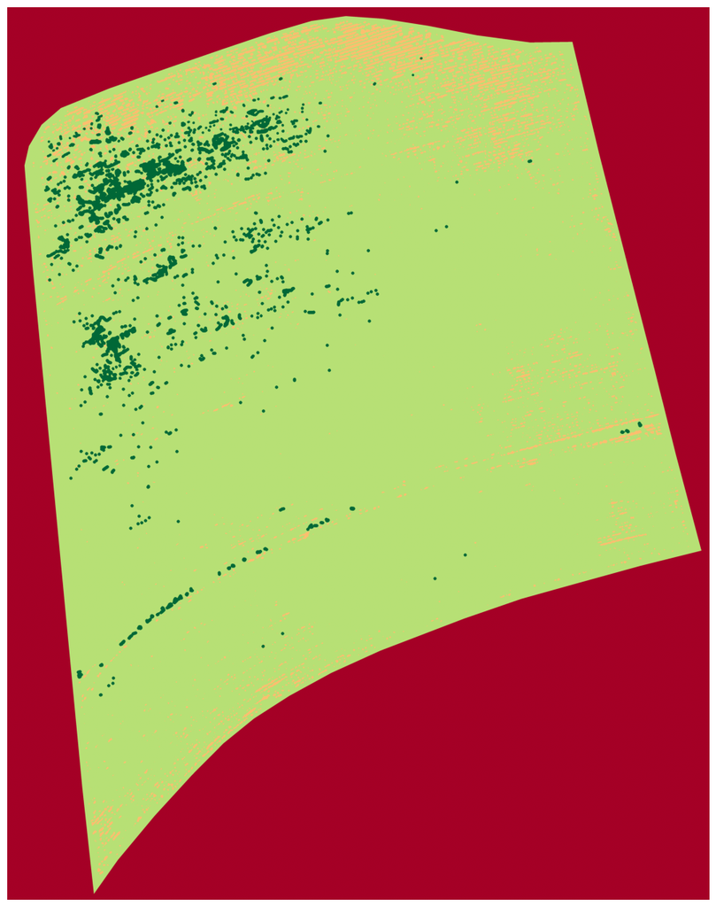

```python
plt.figure(figsize=[16,16])
plt.imshow(gt, cmap='RdYlGn')
plt.axis('off')
```

```python
gt
```

```
array([[0, 0, 0, ..., 0, 0, 0],
       [0, 0, 0, ..., 0, 0, 0],
       [0, 0, 0, ..., 0, 0, 0],
       ...,
       [0, 0, 0, ..., 0, 0, 0],
       [0, 0, 0, ..., 0, 0, 0],
       [0, 0, 0, ..., 0, 0, 0]])
```

Now let's divide the RGB image and the mask into 256x256 patches:

```python
from os import mkdir
```

```python
mkdir('output')
```

```python
OUTPUT_DIR = "/content/output"
TARGET_SIZE = 256
```

```python
k = 0
for y in range(0, rgb_img.shape[0], TARGET_SIZE):
    for x in range(0, rgb_img.shape[1], TARGET_SIZE):
        img_tile = rgb_img[y:y + TARGET_SIZE, x:x + TARGET_SIZE]
        mask_tile = gt[y:y + TARGET_SIZE, x:x + TARGET_SIZE]

        if img_tile.shape[0] == TARGET_SIZE and img_tile.shape[1] == TARGET_SIZE:
          if not (mask_tile.mean() == 0 or mask_tile.mean() == 2) :
            out_img_path = os.path.join(OUTPUT_DIR, "img_{}.png".format(k))
            io.imsave(out_img_path, img_tile)

            out_mask_path = os.path.join(OUTPUT_DIR, "msk_{}.png".format(k))
            cv2.imwrite(out_mask_path, mask_tile)
            k += 1
```

Now let's create the X variable to receive the RGB and Y patches for the mask patches.

```python
list_img = [f for f in os.listdir(OUTPUT_DIR) if f.startswith('img')]
list_msk = [f for f in os.listdir(OUTPUT_DIR) if f.startswith('msk')]
```

```python
list_img.sort()
list_msk.sort()
```

```python
X = []
for path_img in list_img:
  full_path = os.path.join(OUTPUT_DIR, path_img)
  img = io.imread(full_path)
  X.append(img)
```

```python
Y = []
for path_msk in list_msk:
  full_path = os.path.join(OUTPUT_DIR, path_msk)
  msk = io.imread(full_path)
  Y.append(msk)
```

```python
X = np.array(X)
Y = np.array(Y)
```

```python
X.shape
```

```
(342, 256, 256, 4)
```

Let's visualize the data:

```
(-0.5, 255.5, 255.5, -0.5)
```

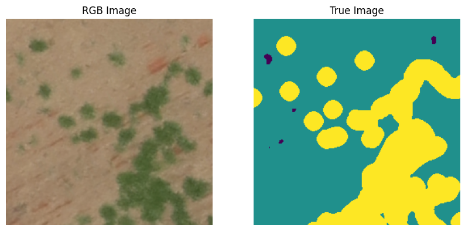

```python
i = 54
plt.figure(figsize=[10,10])
plt.subplot(121)
plt.imshow(X[i,:,:,:])
plt.title('RGB Image')
plt.axis('off')
plt.subplot(122)
plt.imshow(Y[i,:,:])
plt.title('True Image')
plt.axis('off')
```

Let's apply the one hot encoder to the labels:

```python
from keras.models import Model
from keras.regularizers import l2
from keras.layers import *
from keras.models import *
import keras.backend as K
import tensorflow as tf
from tensorflow.keras.preprocessing.image import ImageDataGenerator
#from tensorflow.keras.optimizers import Adam
from keras.optimizers import Adam
from tensorflow.keras.losses import Tversky
```

```python
Y = to_categorical(Y,len(class_names_list))
```

```python
Y.shape
```

```
(342, 256, 256, 4)
```

Here we will divide the dataset into training and testing:

```python
x_train, x_test, y_train, y_test = train_test_split(X, Y, test_size=0.3, random_state=10)
```

```python
x_train = x_train/255
x_test = x_test/255
```

```python
y_train = y_train.astype('float')
y_test = y_test.astype('float')
```

We have implemented data augmentation:

```python
img_datagen = ImageDataGenerator(
    rotation_range=90,
    vertical_flip = True,
    horizontal_flip=True)

mask_datagen = ImageDataGenerator(
    rotation_range=90,
    vertical_flip = True,
    horizontal_flip=True)
```

```python
img_datagen.fit(x_train, augment=True,seed=1200)
mask_datagen.fit(y_train, augment=True,seed=1200)
```

```python
train_generator=img_datagen.flow(x_train,y_train,batch_size=8,seed=1200)
```

```python
steps_per_epoch = len(x_train)//8
validation_steps = len(x_test)//8
```

```python
len(x_test)/8
```

```
12.875
```

```python
steps_per_epoch = len(x_train)//8
validation_steps = len(x_test)//8
```

```python
n_classe = 4
```

And then we can build DeepLabV3+:

```python
import keras
from keras import layers
from keras import ops

def convolution_block(
    block_input,
    num_filters=256,
    kernel_size=3,
    dilation_rate=1,
    use_bias=False,
):
    x = layers.Conv2D(
        num_filters,
        kernel_size=kernel_size,
        dilation_rate=dilation_rate,
        padding="same",
        use_bias=use_bias,
        kernel_initializer=keras.initializers.HeNormal(),
    )(block_input)
    x = layers.BatchNormalization()(x)
    return ops.nn.relu(x)


def DilatedSpatialPyramidPooling(dspp_input):
    dims = dspp_input.shape
    x = layers.AveragePooling2D(pool_size=(dims[-3], dims[-2]))(dspp_input)
    x = convolution_block(x, kernel_size=1, use_bias=True)
    out_pool = layers.UpSampling2D(
        size=(dims[-3] // x.shape[1], dims[-2] // x.shape[2]),
        interpolation="bilinear",
    )(x)

    out_1 = convolution_block(dspp_input, kernel_size=1, dilation_rate=1)
    out_6 = convolution_block(dspp_input, kernel_size=3, dilation_rate=6)
    out_12 = convolution_block(dspp_input, kernel_size=3, dilation_rate=12)
    out_18 = convolution_block(dspp_input, kernel_size=3, dilation_rate=18)

    x = layers.Concatenate(axis=-1)([out_pool, out_1, out_6, out_12, out_18])
    output = convolution_block(x, kernel_size=1)
    return output
```

```python
def DeeplabV3Plus(image_size, num_classes):
    model_input = keras.Input(shape=image_size)
    preprocessed = keras.applications.resnet50.preprocess_input(model_input)
    resnet50 = keras.applications.ResNet50(
        weights="imagenet", include_top=False, input_tensor=preprocessed
    )
    x = resnet50.get_layer("conv4_block6_2_relu").output
    x = DilatedSpatialPyramidPooling(x)

    input_a = layers.UpSampling2D(
        size=(image_size[0] // 4 // x.shape[1], image_size[1] // 4 // x.shape[2]),
        interpolation="bilinear",
    )(x)
    input_b = resnet50.get_layer("conv2_block3_2_relu").output
    input_b = convolution_block(input_b, num_filters=48, kernel_size=1)

    x = layers.Concatenate(axis=-1)([input_a, input_b])
    x = convolution_block(x)
    x = convolution_block(x)
    x = layers.UpSampling2D(
        size=(image_size[0] // x.shape[1], image_size[1] // x.shape[2]),
        interpolation="bilinear",
    )(x)
    model_output = layers.Conv2D(num_classes, kernel_size=(1, 1), activation='sigmoid', padding="same")(x)
    return keras.Model(inputs=model_input, outputs=model_output)


model = DeeplabV3Plus(image_size=x_train.shape[1:], num_classes=n_classe)
model.compile(optimizer=Adam(learning_rate = 1e-5), loss = Tversky, metrics=[ 'accuracy'])
model.summary()
```

```
Model: "functional_1"
```

```
┏━━━━━━━━━━━━━━━━━━━━━━━━━━━┳━━━━━━━━━━━━━━━━━━━━━━━━┳━━━━━━━━━━━━━━━━┳━━━━━━━━━━━━━━━━━━━━━━━━┓
┃ Layer (type)              ┃ Output Shape           ┃        Param # ┃ Connected to           ┃
┡━━━━━━━━━━━━━━━━━━━━━━━━━━━╇━━━━━━━━━━━━━━━━━━━━━━━━╇━━━━━━━━━━━━━━━━╇━━━━━━━━━━━━━━━━━━━━━━━━┩
│ input_layer_1             │ (None, 256, 256, 4)    │              0 │ -                      │
│ (InputLayer)              │                        │                │                        │
├───────────────────────────┼────────────────────────┼────────────────┼────────────────────────┤
│ get_item_3 (GetItem)      │ (None, 256, 256)       │              0 │ input_layer_1[0][0]    │
├───────────────────────────┼────────────────────────┼────────────────┼────────────────────────┤
│ get_item_4 (GetItem)      │ (None, 256, 256)       │              0 │ input_layer_1[0][0]    │
├───────────────────────────┼────────────────────────┼────────────────┼────────────────────────┤
│ get_item_5 (GetItem)      │ (None, 256, 256)       │              0 │ input_layer_1[0][0]    │
├───────────────────────────┼────────────────────────┼────────────────┼────────────────────────┤
│ stack_1 (Stack)           │ (None, 256, 256, 3)    │              0 │ get_item_3[0][0],      │
│                           │                        │                │ get_item_4[0][0],      │
│                           │                        │                │ get_item_5[0][0]       │
├───────────────────────────┼────────────────────────┼────────────────┼────────────────────────┤
│ add_1 (Add)               │ (None, 256, 256, 3)    │              0 │ stack_1[0][0]          │
├───────────────────────────┼────────────────────────┼────────────────┼────────────────────────┤
│ conv1_pad (ZeroPadding2D) │ (None, 262, 262, 3)    │              0 │ add_1[0][0]            │
├───────────────────────────┼────────────────────────┼────────────────┼────────────────────────┤
│ conv1_conv (Conv2D)       │ (None, 128, 128, 64)   │          9,472 │ conv1_pad[0][0]        │
├───────────────────────────┼────────────────────────┼────────────────┼────────────────────────┤
│ conv1_bn                  │ (None, 128, 128, 64)   │            256 │ conv1_conv[0][0]       │
│ (BatchNormalization)      │                        │                │                        │
├───────────────────────────┼────────────────────────┼────────────────┼────────────────────────┤
│ conv1_relu (Activation)   │ (None, 128, 128, 64)   │              0 │ conv1_bn[0][0]         │
├───────────────────────────┼────────────────────────┼────────────────┼────────────────────────┤
│ pool1_pad (ZeroPadding2D) │ (None, 130, 130, 64)   │              0 │ conv1_relu[0][0]       │
├───────────────────────────┼────────────────────────┼────────────────┼────────────────────────┤
│ pool1_pool (MaxPooling2D) │ (None, 64, 64, 64)     │              0 │ pool1_pad[0][0]        │
├───────────────────────────┼────────────────────────┼────────────────┼────────────────────────┤
│ conv2_block1_1_conv       │ (None, 64, 64, 64)     │          4,160 │ pool1_pool[0][0]       │
│ (Conv2D)                  │                        │                │                        │
├───────────────────────────┼────────────────────────┼────────────────┼────────────────────────┤
│ conv2_block1_1_bn         │ (None, 64, 64, 64)     │            256 │ conv2_block1_1_conv[0… │
│ (BatchNormalization)      │                        │                │                        │
├───────────────────────────┼────────────────────────┼────────────────┼────────────────────────┤
│ conv2_block1_1_relu       │ (None, 64, 64, 64)     │              0 │ conv2_block1_1_bn[0][… │
│ (Activation)              │                        │                │                        │
├───────────────────────────┼────────────────────────┼────────────────┼────────────────────────┤
```

[output cut: 458 more lines]

```
├───────────────────────────┼────────────────────────┼────────────────┼────────────────────────┤
│ relu_16 (Relu)            │ (None, 64, 64, 256)    │              0 │ batch_normalization_1… │
├───────────────────────────┼────────────────────────┼────────────────┼────────────────────────┤
│ conv2d_18 (Conv2D)        │ (None, 64, 64, 256)    │        589,824 │ relu_16[0][0]          │
├───────────────────────────┼────────────────────────┼────────────────┼────────────────────────┤
│ batch_normalization_17    │ (None, 64, 64, 256)    │          1,024 │ conv2d_18[0][0]        │
│ (BatchNormalization)      │                        │                │                        │
├───────────────────────────┼────────────────────────┼────────────────┼────────────────────────┤
│ relu_17 (Relu)            │ (None, 64, 64, 256)    │              0 │ batch_normalization_1… │
├───────────────────────────┼────────────────────────┼────────────────┼────────────────────────┤
│ up_sampling2d_5           │ (None, 256, 256, 256)  │              0 │ relu_17[0][0]          │
│ (UpSampling2D)            │                        │                │                        │
├───────────────────────────┼────────────────────────┼────────────────┼────────────────────────┤
│ conv2d_19 (Conv2D)        │ (None, 256, 256, 4)    │          1,028 │ up_sampling2d_5[0][0]  │
└───────────────────────────┴────────────────────────┴────────────────┴────────────────────────┘
```

```
 Total params: 11,853,124 (45.22 MB)
```

```
 Trainable params: 11,820,388 (45.09 MB)
```

```
 Non-trainable params: 32,736 (127.88 KB)
```

```python
history = model.fit(train_generator,steps_per_epoch=steps_per_epoch, validation_steps=validation_steps,
                              epochs=300, validation_data=(x_test,y_test))
```

```
29/29 ━━━━━━━━━━━━━━━━━━━━ 638s 20s/step - accuracy: 0.2491 - loss: 0.6470 - val_accuracy: 0.0711 - val_loss: 0.6793
 1/29 ━━━━━━━━━━━━━━━━━━━━ 8:18 18s/step - accuracy: 0.6227 - loss: 0.5518
```

```
29/29 ━━━━━━━━━━━━━━━━━━━━ 34s 572ms/step - accuracy: 0.6227 - loss: 0.5518
 2/29 ━━━━━━━━━━━━━━━━━━━━ 8:22 19s/step - accuracy: 0.4699 - loss: 0.6014
```

[figure not shown]

[figure not shown]

```python
plt.plot(history.history['accuracy'])
plt.plot(history.history['val_accuracy'])
plt.title('model accuracy')
plt.ylabel('accuracy')
plt.xlabel('epoch')
plt.legend(['train', 'val'], loc='lower right')
plt.show()

plt.plot(history.history['loss'])
plt.plot(history.history['val_loss'])
plt.title('model loss')
plt.ylabel('loss')
plt.xlabel('epoch')
plt.legend(['train', 'test'], loc='upper right')
plt.show()
```

After training, we will obtain some validation metrics:

```python
from keras.models import model_from_json
from sklearn.metrics import classification_report
from sklearn.metrics import confusion_matrix
import pandas as pd
import seaborn as sns
from sklearn.metrics import f1_score
from sklearn.metrics import recall_score
from sklearn.metrics import cohen_kappa_score
```

We start by calculating the accuracy for the test set:

```python
predict = model.predict(x_test)
```

```python
predict = np.round(predict)
```

```python
pred = np.argmax(predict, axis=3)
```

```python
true = np.argmax(y_test, axis=3)
```

Accuracy:

```python
accuracy = accuracy_score(true.flatten(),pred.flatten())
print(accuracy)
```

```
0.9479219010732707
```

F1 Score:

```python
f1_score(true.flatten(), pred.flatten(), average='macro')
```

```
0.7527458780899748
```

```python
f1_score(true.flatten(), pred.flatten(), average='micro')
```

```
0.9479219010732707
```

```python
f1_score(true.flatten(), pred.flatten(), average='weighted')
```

```
0.9395697605269571
```

Recall:

```python
recall_score(true.flatten(), pred.flatten(), average='macro')
```

```
0.7117527073740617
```

Kappa

```python
cohen_kappa_score(true.flatten(), pred.flatten())
```

```
0.8385617288552756
```

Confusion Matrix:

```python
cm = confusion_matrix(true.flatten(), pred.flatten())
print(cm)
```

```
[[ 875568       0     381     175]
 [   9519   86870  161540   32956]
 [  28130   21241 5326131   11174]
 [   5044     107   81271  110101]]
```

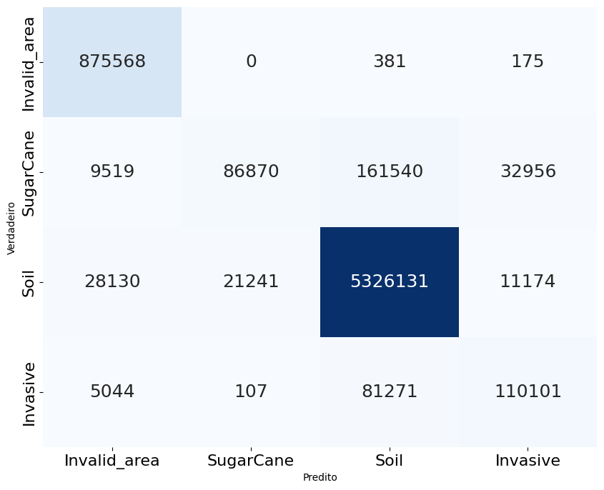

```python
columns = class_names_list
r1 = pd.DataFrame(data=cm, columns=columns, index=columns)
fig, ax = plt.subplots(figsize=(10,8))
ax = sns.heatmap(r1, annot=True, annot_kws={"size": 18},fmt='d',cmap="Blues", cbar = False)
#for t in ax.texts: t.set_text(t.get_text() + " %")
ax.tick_params(labelsize=16)
ax.set_ylabel('Verdadeiro')
ax.set_xlabel('Predito')
```

Finally, let's plot an example of the predicted result compared to the original mask:

```
(-0.5, 255.5, 255.5, -0.5)
```

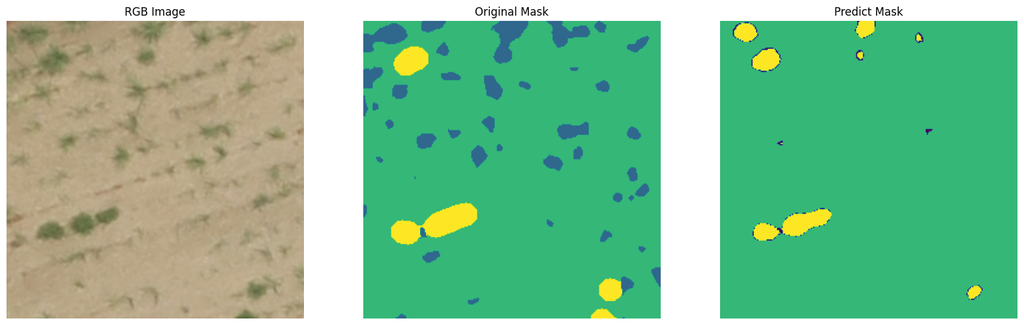

```python
i = 10
plt.figure(figsize=[20,8])
plt.subplot(131)
plt.imshow(x_test[i])
plt.title('RGB Image')
plt.axis('off')
plt.subplot(132)
plt.imshow(true[i], vmin=0,vmax=3)
plt.title('Original Mask')
plt.axis('off')
plt.subplot(133)
plt.imshow(pred[i], vmin=0,vmax=3)
plt.title('Predict Mask')
plt.axis('off')
```

We can also save the trained architecture and weights:

```python
# serialize model to JSON
model_json = model.to_json()
with open("/content/drive/MyDrive/Datasets/Cana weeds/Deeplabv3.json", "w") as json_file:
    json_file.write(model_json)
# serialize weights to HDF5
model.save_weights("/content/drive/MyDrive/Datasets/Cana weeds/Model300.weights.h5")
```